# 分析中職球員影響力

110071025 計財大三 張智傑

## 一、摘要

- 透過中華職棒大聯盟中的數據觀察中職各隊表現優異的球員，分析對於比賽戰績的影響力，以及是否被選入過去的國際賽名單中，並預測是否入選今年年底12強名單。
- 不過最終分析結果發現表現優異球員數量多寡與球隊戰績沒有顯著性，且國際賽預測準確率偏低，說明只以單一指標當作KPI有偏誤，會忽略了其他棒球場上的重要數據，符合棒球界想法，也就是至今仍無法用單一指標評判球員帶來的價值及影響力。

## 二、研究動機及主題

棒球常被稱作是台灣的國球，也因此只要遇到國際賽，大家一定都會特別關注，不管是比賽場地、賽程、對手強度等等，特別是選手名單，往往都是各媒體爭論及猜測的焦點，因此自己想透過此次的機會來分析及觀察總教練、球探等人是如何評比、評價及選擇球員的，並最終去預測今年年底12強中職球員入選名單及可能成績為何。

#### 說明：

- 現階段只著重在中職球員身上，旅外、業餘、大專球員暫不考慮，另外，因為「台鋼雄鷹」球隊今年才加入一軍賽事，因此過去幾年沒有資料無法繪圖
- **投手評價指標為ERA+，打者評價指標為OPS+**
- 優異球員的定義：**投手為 ERA+ >= 100, 打者為 OPS+ >= 100**

## 三、資料內容分析及觀察

抓取2022年至2024年6月16日資料，分為打者、投手、團隊成績等

```r
Hitter_data = read_excel("中職資料.xlsx", sheet = "打者成績")
Pitcher_data = read_excel("中職資料.xlsx", sheet = "投手成績")
Team_Record_2024 = read_excel("中職資料.xlsx", sheet = "2024 球隊戰績")
Team_Record_2023 = read_excel("中職資料.xlsx", sheet = "2023 球隊戰績")
Team_Record_2022 = read_excel("中職資料.xlsx", sheet = "2022 球隊戰績")
Hitter_wbc_2023 = read_excel("中職資料.xlsx", sheet = "2023 經典賽打者")
Pitcher_wbc_2023 = read_excel("中職資料.xlsx", sheet = "2023 經典賽投手")
Asiad_2023 = read_excel("中職資料.xlsx", sheet = "2023 亞運")
Abc_2023 = read_excel("中職資料.xlsx", sheet = "2023 亞錦")
Apbc_2023 = read_excel("中職資料.xlsx", sheet = "2023 亞冠")
```

- 打者KPI為OPS+ (加權整體攻擊指數)，是OPS的延伸，OPS代表打者的上壘率+長打率，可代表打者的攻擊能力
- 公式為 *OPS+ = 100 * 球員自身 OPS / 整體聯盟平均 OPS*
- OPS+ 等於100代表等於整體聯盟平均水準，大於100則表示表現優異，小於100則表示表現較差
- 打者主要數據變量：整體攻擊指數(OPS)、守備位置、球隊、年度
- 投手主要數據變量：防禦率(ERA)、角色定位、球隊、年度

```r
#先設定打席數需大於50，以年度區分來計算個別球員OPS+
Hitter_data = Hitter_data |> filter(打席 >= 50) |>
  group_by(年度) |>
  mutate(n = n(),
            n_OPS = sum(整體攻擊指數),
            legend_OPS = n_OPS/n,
            OPS_plus = round(100 * 整體攻擊指數 / legend_OPS, 0))

#透過球隊、年度區分計算平均OPS+並繪圖
D1 = Hitter_data |>
  group_by(球隊,年度) |>
  summarise(mean_OPS_plus = mean(OPS_plus,na.rm = T)) |>
  ggplot() + geom_col(aes(球隊,mean_OPS_plus, fill = 球隊)) +
  theme(legend.position = "none") +
  scale_y_continuous(breaks = 25*(1:6)) +
  labs(x = "球隊",y = "加權平均整體攻擊指數") +
  facet_wrap(~年度) + coord_flip()
```

- 投手KPI為ERA+ (加權防禦率)，是ERA的延伸，ERA代表投手平均每場球所失的自責分，分值越低則代表投手表現越好
- 公式為 *ERA+ = 100 * 整體聯盟平均 ERA / 球員自身 ERA*

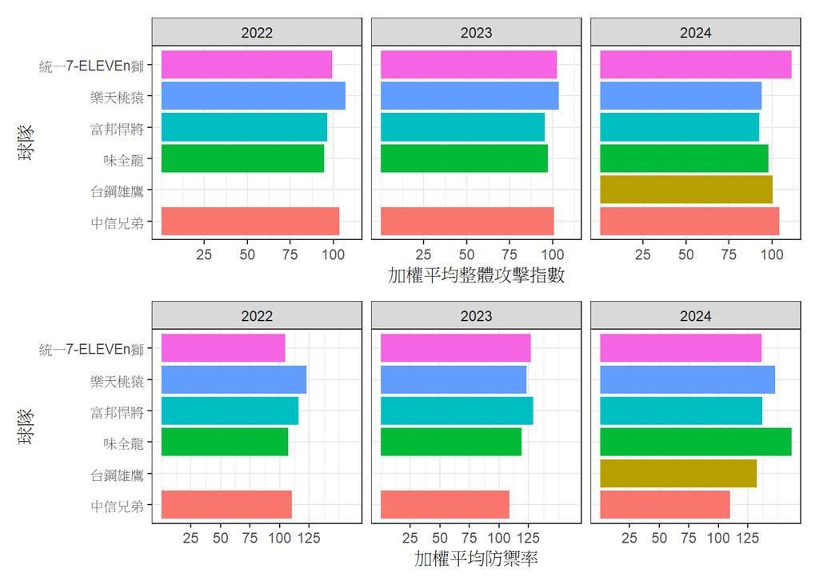

```r
#先處理資料，設定2024年要至少投10局以上，而2022、2023年則是20局
P1 = Pitcher_data |> filter(投球局數 >= 20 & 年度 != 2024)
P2 = Pitcher_data |> filter(投球局數 >= 10 & 年度 == 2024 )
Pitcher_data = bind_rows(P1, P2)

Pitcher_data = Pitcher_data |>
  group_by(年度) |>
  mutate(n = n(),
            n_ERA = sum(防禦率),
            legend_ERA = n_ERA/n,
            ERA_plus = round(100*legend_ERA/防禦率,0))

#透過球隊、年度區分計算平均ERA+並繪圖
D2 = Pitcher_data |>
  group_by(球隊,年度) |>
  summarise(mean_ERA_plus = mean(ERA_plus,na.rm = T)) |>
  ggplot() + geom_col(aes(球隊,mean_ERA_plus, fill = 球隊)) +
  theme(legend.position = "none") +
  scale_y_continuous(breaks = 25*(1:5)) +
  labs(x = "球隊",y = "加權平均防禦率") +
  facet_wrap(~年度) + coord_flip()

D1/D2
```

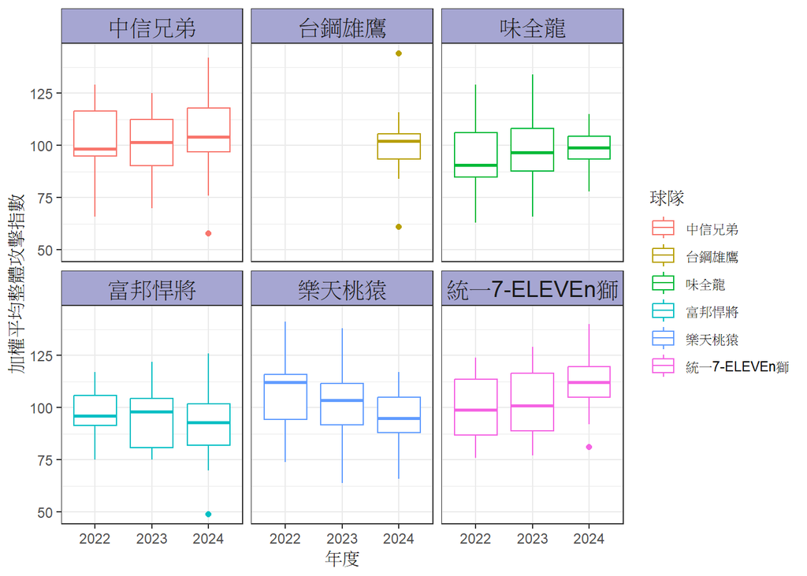

```r
#透過盒狀圖呈現OPS+變化趨勢
Hitter_data |>
  group_by(球隊,年度) |>
  ggplot() + geom_boxplot(aes(as.factor(年度),OPS_plus,
                              col = 球隊)) +
  theme(strip.background = element_rect(fill = "#A6A6D2")) +
  theme(strip.text = element_text(size = 14)) +
  labs(x = "年度",y = "加權平均整體攻擊指數") +
  facet_wrap(~球隊)
```

在2022~2024年間，有三隊的平均OPS+節節上升，分別是中信兄弟、味全龍、統一7-ELEVEn獅，而樂天桃猿則是逐漸下降，富邦悍將每年都低於聯盟平均，也同時發現今年中信兄弟及統一7-ELEVEn獅是打擊狀況最火燙的球隊

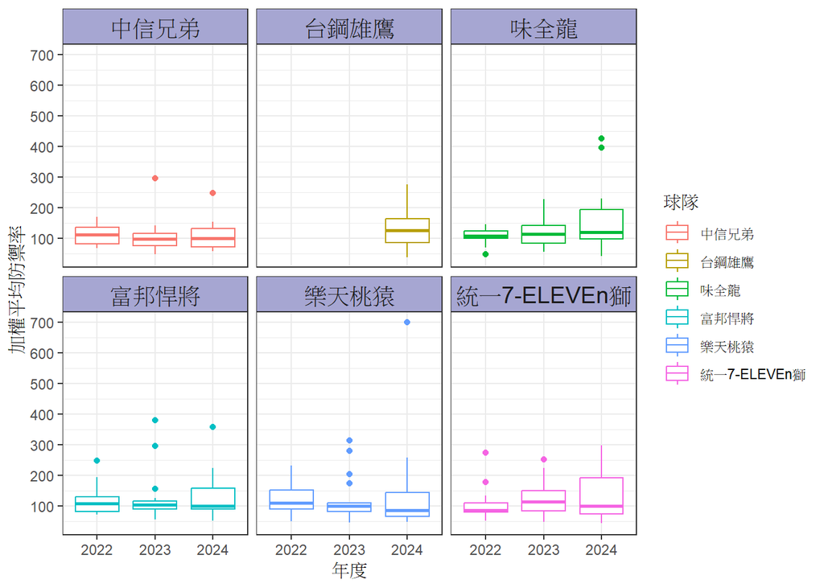

```r
#透過盒狀圖呈現ERA+變化趨勢
Pitcher_data |>
  group_by(球隊,年度) |>
  ggplot() + geom_boxplot(aes(as.factor(年度),ERA_plus,
                              col = 球隊)) +
  theme(strip.background = element_rect(fill = "#A6A6D2")) +
  theme(strip.text = element_text(size = 14)) +
  scale_y_continuous(breaks = 100*(1:7)) +
  labs(x = "年度",y = "加權平均防禦率") +
  facet_wrap(~球隊)
```

投手部分可發現各隊幾乎都有離群值，代表表現大幅超越聯盟平均，不過以整體來說，味全龍投手表現節節上升，而富邦悍將及樂天桃猿都有小幅下滑

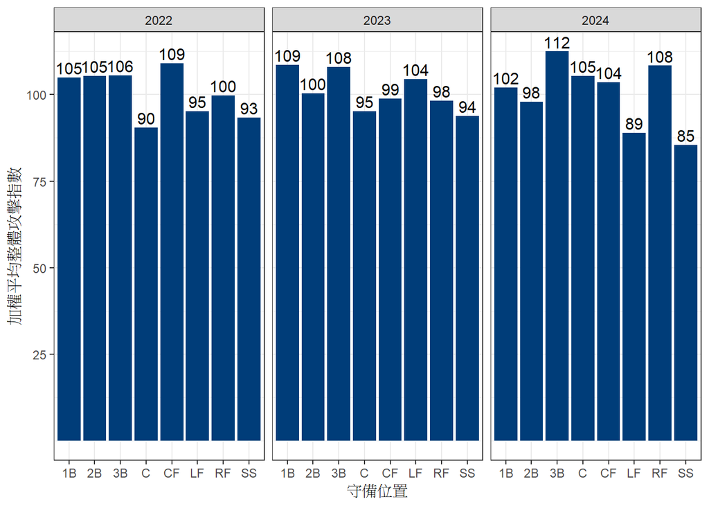

```r
#透過守備位置、年度區分計算平均OPS+並繪圖
Hitter_data |>
  group_by(守備位置,年度) |>
  summarise(mean_OPS_plus = mean(OPS_plus,na.rm = T)) |>
  ggplot() + geom_col(aes(守備位置,mean_OPS_plus), fill = "#003D79") +
  geom_text(aes(守備位置, mean_OPS_plus, label = round(mean_OPS_plus)),
            vjust = -0.3, color = "black", size = 4) +
  scale_y_continuous(breaks = 25*(1:5)) +
  labs(x = "守備位置",y = "加權平均整體攻擊指數") +
  facet_wrap(~年度)
```

今年在3B、RF的球員表現突出，2023年是1B、3B較為突出，2022年則是CF、2B、3B，推薦3B球員表現優異可能是因為防守角落內野，對於守備較沒有要求，可以選擇打擊火力強的球員；不過SS的球員普遍表現低於聯盟平均，可能是因為此守備位置需要防守能力較優異的球員，所以犧牲了部分的打擊火力

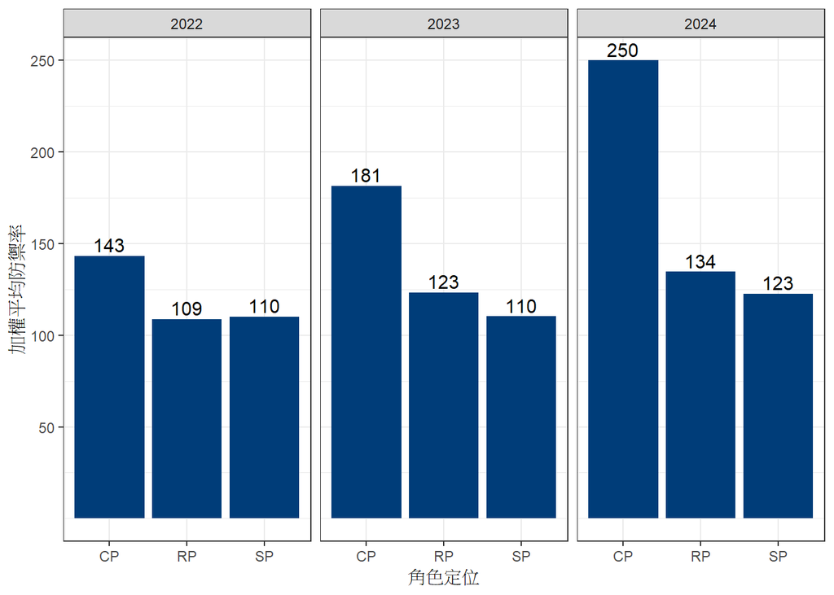

```r
#透過角色定位、年度區分計算平均ERA+並繪圖
Pitcher_data |>
  group_by(角色定位,年度) |>
  summarise(mean_ERA_plus = mean(ERA_plus,na.rm = T)) |>
  ggplot() + geom_col(aes(角色定位,mean_ERA_plus), fill = "#003D79") +
  geom_text(aes(角色定位, mean_ERA_plus, label = round(mean_ERA_plus)),
            vjust = -0.3, color = "black", size = 4) +
  scale_y_continuous(breaks = 50*(1:5)) +
  labs(x = "角色定位",y = "加權平均防禦率") +
  facet_wrap(~年度)
```

今年CP(終結者)表現相當好，且往往是三種角色中表現最好的，推測是因為球隊通常只會把這個位置給厲害球員(1~2人)，不像其他兩種角色球員數較多可能會拉低平均

#### 設定OPS+、ERA+需大於100，也就是優於聯盟平均

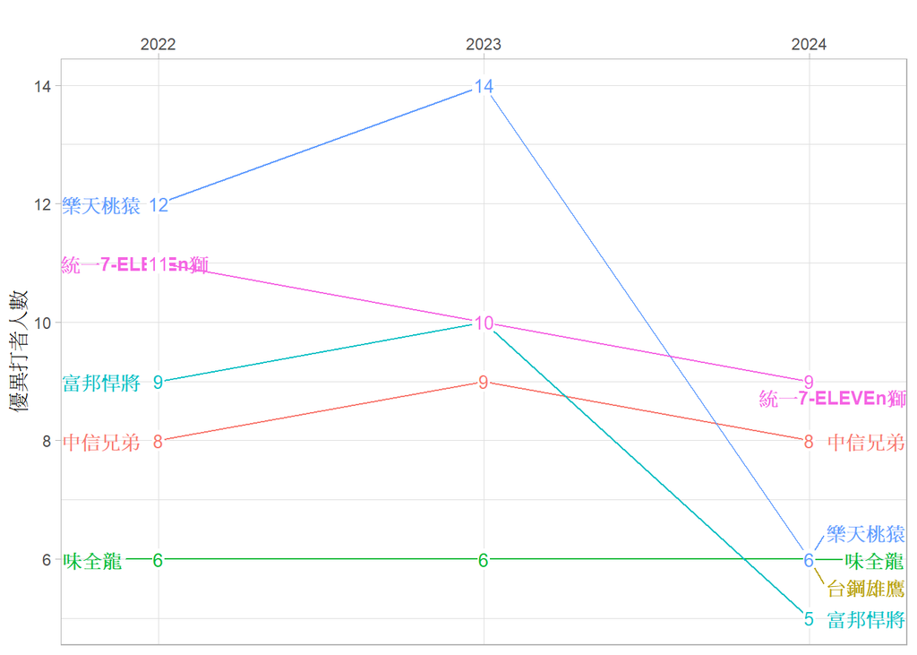

```r
#先找出優於聯盟平均打者，以年度、球隊區分計算人數並繪圖
Hitter_data |> filter(OPS_plus >= 100) |>
  group_by(球隊, 年度) |>
  summarise(KPI = n()) |>
  ggplot(aes(factor(年度), KPI, group = 球隊)) +
  geom_line(aes(col = 球隊), show.legend = FALSE) +
  geom_text_repel(data = . %>% filter(年度 == 2024),
                  aes(label = 球隊, col = 球隊),
                  hjust = 0, fontface = "bold", direction = "y",
                  size = 3.5, nudge_x = 0.2, show.legend = FALSE) +
  geom_text_repel(data = . %>% filter(年度 == 2022),
                  aes(label = 球隊, col = 球隊),
                  hjust = 1, fontface = "bold", direction = "y",
                  size = 3.5, nudge_x = -0.2, show.legend = FALSE) +
  geom_label(aes(label = round(KPI), col = 球隊),
             size = 3.5, label.padding = unit(0.05, "lines"),
             label.size = 0.0, show.legend = FALSE) +
  scale_x_discrete(expand = c(0.1, 0.1), position = "top") +
  scale_y_continuous(breaks = seq(2, 14, by = 2)) +
  labs(x = "", y = "優異打者人數") +
  theme_light()
```

2022、2023年樂天桃猿都有最多的表現優異球員，而今年則是中信兄弟及統一7-ELEVEn獅有較多表現優異球員，與各球隊平均OPS+高低有正相關性，不過今年優異打者人數似乎較2022、2023年來得遜色

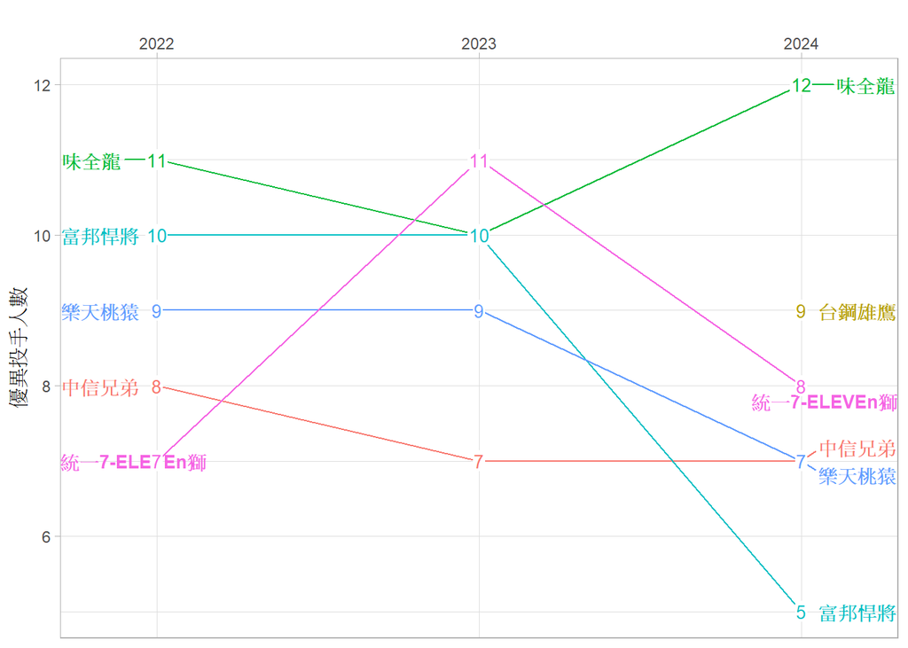

```r
#先找出優於聯盟平均投手，以球隊、年度區分計算人數並繪圖
Pitcher_data |> filter(ERA_plus >= 100) |>
  group_by(球隊, 年度) |>
  summarise(KPI = n()) |>
  ggplot(aes(factor(年度), KPI, group = 球隊)) +
  geom_line(aes(col = 球隊), show.legend = FALSE) +
  geom_text_repel(data = . %>% filter(年度 == 2024),
                  aes(label = 球隊, col = 球隊),
                  hjust = 0, fontface = "bold", direction = "y",
                  size = 3.5, nudge_x = 0.2, show.legend = FALSE) +
  geom_text_repel(data = . %>% filter(年度 == 2022),
                  aes(label = 球隊, col = 球隊),
                  hjust = 1, fontface = "bold", direction = "y",
                  size = 3.5, nudge_x = -0.2, show.legend = FALSE) +
  geom_label(aes(label = round(KPI), col = 球隊),
             size = 3.5, label.padding = unit(0.05, "lines"),
             label.size = 0.0, show.legend = FALSE) +
  scale_x_discrete(expand = c(0.1, 0.1), position = "top") +
  labs(x = "", y = "優異投手人數") +
  theme_light()
```

2022~2024年間，味全龍幾乎都在第一名的位置，而統一7-ELEVEn獅則是大起又大落，然後2024年味全龍與其他球隊的差距蠻大的

```r
#先找出優於聯盟平均打者，以年度、守備位置區分計算人數並繪圖
D3 = Hitter_data |> filter(OPS_plus >= 100) |>
  group_by(守備位置) |>
  summarise(KPI = n()) |>
  ggplot() + geom_col(aes(fct_infreq(守備位置,KPI),KPI), fill = "#003D79") +
  geom_text(aes(fct_infreq(守備位置, KPI), KPI, label = KPI),
            vjust = 1.2, color = "white") +
  scale_y_continuous(breaks = 3*(1:10)) +
  labs(x = "守備位置", y = "優異球員人數")
```

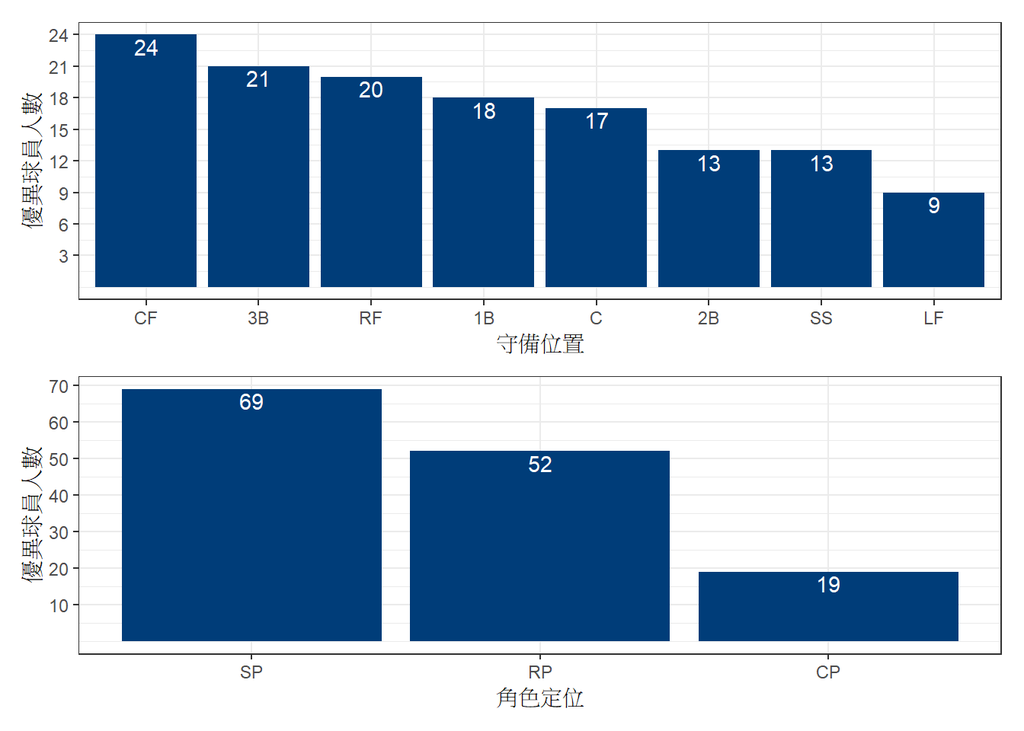

```r
#先找出優於聯盟平均投手，以角色定位、年度區分計算人數並繪圖
D4 = Pitcher_data |> filter(ERA_plus >= 100) |>
  group_by(角色定位) |>
  summarise(KPI = n()) |>
  ggplot() + geom_col(aes(fct_infreq(角色定位,KPI),KPI), fill = "#003D79") +
  geom_text(aes(fct_infreq(角色定位, KPI), KPI, label = KPI),
            vjust = 1.2, color = "white") +
  scale_y_continuous(breaks = 10*(1:10)) +
  labs(x = "角色定位",y = "優異球員人數")

D3/D4
```

打者部分，這三年來，CF、3B位置的表現優異球員最多，而LF位置則最少；投手部分，先發投手擁有較多優異球員，可能是因為有許多外籍投手皆為先發投手且表現傑出所導致，然後終結者因為人數較少所以優異球員也較少

```r
D5 = Hitter_data |> filter(OPS_plus >= 100) |>
  group_by(球隊, 守備位置) |>
  summarise(mean_OPS_plus = mean(OPS_plus,na.rm = T)) |>
  ggplot() + geom_col(aes(守備位置,mean_OPS_plus), fill = "#003D79") +
  scale_y_continuous(breaks = seq(25, 175, by = 25)) +
  labs(x = "守備位置",y = "加權平均整體攻擊指數") +
  facet_wrap(~球隊)
```

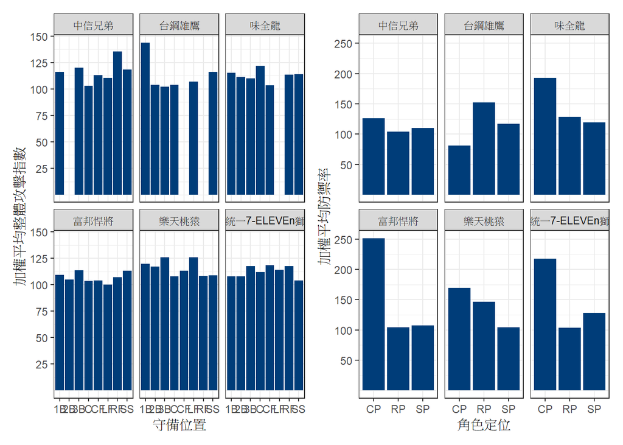

```r
#透過球隊、角色定位區分計算平均ERA+並繪圖
D6 = Pitcher_data |>
  group_by(球隊,角色定位) |>
  summarise(mean_ERA_plus = mean(ERA_plus,na.rm = T)) |>
  ggplot() + geom_col(aes(角色定位,mean_ERA_plus), fill = "#003D79") +
  scale_y_continuous(breaks = 50*(1:5)) +
  labs(x = "角色定位",y = "加權平均防禦率") +
  facet_wrap(~球隊)

D5|D6
```

打者部分，可發現中信兄弟、台鋼雄鷹及味全龍可能在某些守備位置上沒有球員表現超過聯盟平均，因此有缺漏；投手部分，富邦悍將、味全龍及統一7-ELEVEn獅CP表現皆十分突出

## 四、分析與結果

- 首先將2022~2024年各球隊戰績及優異投手、打者人數整併在同一個tibble裡面

```r
#首先處理資料，將資料(勝、和、敗)轉換成可計算的數值
Team_Record_2024 = Team_Record_2024 |>
  separate('勝-和-敗', into = c("勝", "和", "敗"), sep = "-") |>
  mutate(across(c(勝, 和, 敗), as.numeric)) |>
  select(年度, 平均觀眾數, 球隊, 出賽數, 勝, 和, 敗, 勝率)

Team_Record_2023 = Team_Record_2023 |>
  separate('勝-和-敗', into = c("勝", "和", "敗"), sep = "-") |>
  mutate(across(c(勝, 和, 敗), as.numeric)) |>
  select(年度, 平均觀眾數, 球隊, 出賽數, 勝, 和, 敗, 勝率)

Team_Record_2022 = Team_Record_2022 |>
  separate('勝-和-敗', into = c("勝", "和", "敗"), sep = "-") |>
  mutate(across(c(勝, 和, 敗), as.numeric)) |>
  select(年度, 平均觀眾數, 球隊, 出賽數, 勝, 和, 敗, 勝率)

#合併3年各球隊戰績
Team_Record_combined = bind_rows(Team_Record_2024, Team_Record_2023, Team_Record_2022)

#計算每年每支球隊的優異打者及投手數量
Hitter = Hitter_data |> filter(OPS_plus >= 100) |>
  group_by(年度,球隊) |>
  summarise(優異打者數 = n(), .groups = "drop")

Pitcher = Pitcher_data |> filter(ERA_plus >= 100) |>
  group_by(年度,球隊) |>
  summarise(優異投手數 = n(), .groups = "drop")

#計算各球隊平均OPS+、ERA+
Team_OPS_plus = Hitter_data |>
  group_by(球隊,年度) |>
  summarise(mean_OPS_plus = mean(OPS_plus,na.rm = T))

Team_ERA_plus = Pitcher_data |>
  group_by(球隊,年度) |>
  summarise(mean_ERA_plus = mean(ERA_plus,na.rm = T))

#合併優異打者、投手數進入Team_Record_combined
Team_performance = Team_Record_combined |>
  left_join(Hitter, by = c("年度", "球隊")) |>
  left_join(Pitcher, by = c("年度", "球隊")) |>
  left_join(Team_OPS_plus, by = c("年度", "球隊")) |>
  left_join(Team_ERA_plus, by = c("年度", "球隊")) |>
  replace_na(list(優異打者數 = 0, 優異投手數 = 0, mean_OPS_plus = 0, mean_ERA_plus = 0))
```

- 接著透過迴歸分析觀察是否球隊愈多表現優異的球員，代表球隊戰績愈好，設定球隊為Dummy variable

```r
#跑迴歸分析觀察勝率與優異球員數多寡的相關性
model1 = lm(勝率 ~ 優異打者數 + 優異投手數 + 平均觀眾數 + 年度 + I(1*(球隊 == "中信兄弟")) + I(1*(球隊 == "統一7-ELEVEn獅")) + I(1*(球隊 == "樂天桃猿")) + I(1*(球隊 == "富邦悍將")) + I(1*(球隊 == "味全龍")), data = Team_performance)
summary(model1)
```

```
Call:
lm(formula = 勝率 ~ 優異打者數 + 優異投手數 + 平均觀眾數 +
    年度 + I(1 * (球隊 == "中信兄弟")) + I(1 * (球隊 ==
    "統一7-ELEVEn獅")) + I(1 * (球隊 == "樂天桃猿")) +
    I(1 * (球隊 == "富邦悍將")) + I(1 * (球隊 == "味全龍")),
    data = Team_performance)

Residuals:
      Min        1Q    Median        3Q       Max
-0.085672 -0.031911 -0.004849  0.037869  0.087029

Coefficients:
                                    Estimate Std. Error t value Pr(>|t|)
(Intercept)                       -4.282e+01  1.630e+02  -0.263    0.802
優異打者數                        -6.172e-03  1.523e-02  -0.405    0.699
優異投手數                         5.827e-03  1.695e-02   0.344    0.743
平均觀眾數                        -1.433e-05  5.981e-05  -0.240    0.819
年度                               2.141e-02  8.074e-02   0.265    0.800
I(1 * (球隊 == "中信兄弟"))        1.639e-01  1.131e-01   1.450    0.197
I(1 * (球隊 == "統一7-ELEVEn獅"))  1.216e-01  1.321e-01   0.920    0.393
I(1 * (球隊 == "樂天桃猿"))        1.665e-01  1.140e-01   1.461    0.194
I(1 * (球隊 == "富邦悍將"))        2.524e-02  1.089e-01   0.232    0.824
I(1 * (球隊 == "味全龍"))          7.747e-02  1.007e-01   0.769    0.471

Residual standard error: 0.07561 on 6 degrees of freedom
Multiple R-squared:  0.5131,    Adjusted R-squared:  -0.2172
F-statistic: 0.7026 on 9 and 6 DF,  p-value: 0.6959
```

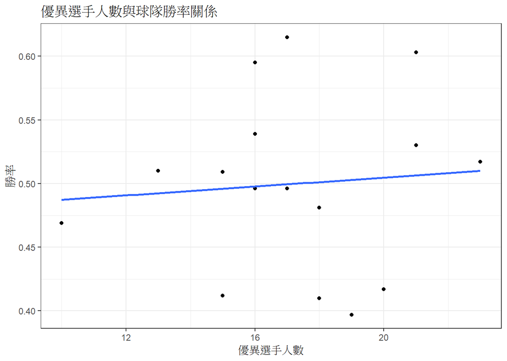

```r
Team_performance |> group_by(年度) |>
  ggplot(aes(x = 優異投手數+優異打者數, y = 勝率)) +
  geom_point() +
  geom_smooth(method = "lm", se = FALSE) +
  labs(title = "優異選手人數與球隊勝率關係", x = "優異選手人數", y = "勝率")
```

發現不管是優異打者數，抑或是優異投手數，對於球隊勝率來說都沒有顯著性，整體迴歸式也呈現不顯著，可推測球隊勝率及戰績會受到更多事物的影響，且只觀察優異選手數量過於單一，可多添加成績等自變量來觀察

```r
#加入團隊平均OPS+及ERA+去觀察
model2 = lm(勝率 ~ 優異打者數 + 優異投手數 + 平均觀眾數 + 年度 + I(1*(球隊 == "中信兄弟")) + I(1*(球隊 == "統一7-ELEVEn獅")) + I(1*(球隊 == "樂天桃猿")) + I(1*(球隊 == "富邦悍將")) + I(1*(球隊 == "味全龍")) + mean_OPS_plus + mean_ERA_plus, data = Team_performance)
summary(model2)
```

```
Call:
lm(formula = 勝率 ~ 優異打者數 + 優異投手數 + 平均觀眾數 +
    年度 + I(1 * (球隊 == "中信兄弟")) + I(1 * (球隊 ==
    "統一7-ELEVEn獅")) + I(1 * (球隊 == "樂天桃猿")) +
    I(1 * (球隊 == "富邦悍將")) + I(1 * (球隊 == "味全龍")) +
    mean_OPS_plus + mean_ERA_plus, data = Team_performance)

Residuals:
         1          2          3          4          5          6          7
-1.618e-02 -1.758e-02 -1.225e-02 -1.834e-02  3.045e-02 -2.862e-17  1.788e-02
         8          9         10         11         12         13         14
 3.593e-02  5.913e-03 -1.356e-02  2.162e-02  1.167e-02  2.581e-02  4.585e-04
        15         16
-1.975e-02 -5.208e-02

Coefficients:
                                    Estimate Std. Error t value Pr(>|t|)
(Intercept)                       -1.142e+02  1.593e+02  -0.717   0.5128
優異打者數                        -2.167e-02  1.064e-02  -2.037   0.1113
優異投手數                         4.360e-03  1.255e-02   0.347   0.7458
平均觀眾數                        -4.416e-05  4.586e-05  -0.963   0.3901
年度                               5.623e-02  7.890e-02   0.713   0.5154
I(1 * (球隊 == "中信兄弟"))        1.625e-01  7.249e-02   2.241   0.0885 .
I(1 * (球隊 == "統一7-ELEVEn獅"))  8.161e-02  8.020e-02   1.018   0.3664
I(1 * (球隊 == "樂天桃猿"))        2.153e-01  8.179e-02   2.633   0.0580 .
I(1 * (球隊 == "富邦悍將"))        1.039e-01  6.958e-02   1.493   0.2097
I(1 * (球隊 == "味全龍"))          1.144e-01  6.158e-02   1.858   0.1367
mean_OPS_plus                      1.435e-02  4.036e-03   3.556   0.0237 *
mean_ERA_plus                     -1.322e-03  2.189e-03  -0.604   0.5785
---
Signif. codes:  0 '***' 0.001 '**' 0.01 '*' 0.05 '.' 0.1 ' ' 1

Residual standard error: 0.04524 on 4 degrees of freedom
Multiple R-squared:  0.8838,    Adjusted R-squared:  0.5642
F-statistic: 2.766 on 11 and 4 DF,  p-value: 0.1691
```

儘管整體迴歸式仍不顯著，但團隊平均OPS+與勝率呈現顯著相關，而樂天桃猿、中信兄弟則呈現近似顯著，說明打擊表現愈好，可以幫助球隊提升勝率

## 五、回測與預測國際賽球員名單

- 雖然透過迴歸式目前無法判斷投手指標(ERA+)及人數對於球隊戰績的影響力，不過正常來說有愈多好的選手代表可以幫助球隊增強戰力，也會被挑選進國際賽名單代表出賽。
- 因此，接下來同樣都是依照打者指標(OPS+)、投手指標(ERA+)來選擇球員，根據不同守備位置、角色定位選出各年表現優異的球員，且設定年齡須小於等於35歲，然後去預測可能入選國際賽的選手 (經典賽選30名球員、亞冠賽選26名球員、12強賽選28名球員)
1. 根據2022年資料預測入選2023年初經典賽的球員

```r
#先設定外籍球員並於篩選球員時排除
foreign_players <- c("安得勝", "羅昂", "德保拉", "伍鐸", "後勁","泰樂","羅力","富藍戈","象魔力","鋼龍")

#設定各個守備位置挑選2名球員
Best_hitter_2022 = Hitter_data |>
  filter(年度 == 2022,年齡 <= 35) |>
  group_by(守備位置) |>
  slice_max(OPS_plus, n = 2) |>
  ungroup() |>
  arrange(desc(OPS_plus)) |>
  slice(1:16)

#個別從SP、RP、CP中挑選球員
Best_pitcher_SP_2022 = Pitcher_data |>
  filter(年度 == 2022, 角色定位 == "SP",年齡 <= 35, !球員 %in% foreign_players) |>
  slice_max(ERA_plus, n = 5)

Best_pitcher_RP_2022 = Pitcher_data |>
  filter(年度 == 2022, 角色定位 == "RP",年齡 <= 35, !球員 %in% foreign_players) |>
  slice_max(ERA_plus, n = 7)

Best_pitcher_CP_2022 = Pitcher_data |>
  filter(年度 == 2022, 角色定位 == "CP",年齡 <= 35, !球員 %in% foreign_players) |>
  slice_max(ERA_plus, n = 2)

#合併SP、RP、CP球員名單
Best_pitcher_2022 = bind_rows(Best_pitcher_SP_2022, Best_pitcher_RP_2022, Best_pitcher_CP_2022)

#計算預測與實際相同的球員名單
successful_predictions_hitter = intersect(Best_hitter_2022$球員, Hitter_wbc_2023$球員)

successful_predictions_pitcher = intersect(Best_pitcher_2022$球員, Pitcher_wbc_2023$球員)

#計算預測成功率，減掉底數6位是因最終選進了6名旅外球員，其餘皆為中職球員
(length(successful_predictions_hitter) + length(successful_predictions_pitcher))  / (length(Best_hitter_2022$球員) + length(Best_pitcher_2022$球員) - 6)
```

```
[1] 0.3333333
```

2. 根據2023年資料預測入選2023年底亞冠賽球員名單

```r
#先設定外籍球員並於篩選球員時排除
foreign_players <- c("勝騎士", "威能帝", "德保拉", "伍鐸", "瑞恩","羅昂","布里悍","富藍戈","艾里歐","布雷克","艾普勒","羅力","蘭道爾","鋼龍","克維斯","錡龍","肯特","艾士特")

#設定各個守備位置挑選2名球員，但最終只選出15名球員
Best_hitter_2023 = Hitter_data |>
  filter(年度 == 2023,年齡 <= 35) |>
  group_by(守備位置) |>
  slice_max(OPS_plus, n = 2) |>
  ungroup() |>
  arrange(desc(OPS_plus)) |>
  slice(1:15)

#個別從SP、RP、CP中挑選球員，以及合併球員名單
Best_pitcher_SP_2023 = Pitcher_data |>
  filter(年度 == 2023, 角色定位 == "SP", 年齡 <= 35, !球員 %in% foreign_players) |>
  slice_max(ERA_plus, n = 5)

Best_pitcher_RP_2023 = Pitcher_data |>
  filter(年度 == 2023, 角色定位 == "RP", 年齡 <= 35, !球員 %in% foreign_players) |>
  slice_max(ERA_plus, n = 4)

Best_pitcher_CP_2023 = Pitcher_data |>
  filter(年度 == 2023, 角色定位 == "CP", 年齡 <= 35, !球員 %in% foreign_players) |>
  slice_max(ERA_plus, n = 2)

Best_pitcher_2023 = bind_rows(Best_pitcher_SP_2023, Best_pitcher_RP_2023, Best_pitcher_CP_2023)

#計算預測成功率
successful_prediction_hitter = intersect(Best_hitter_2023$球員, Apbc_2023$打者)
successful_prediction_pitcher = intersect(Best_hitter_2023$球員, Apbc_2023$投手)

#減掉底數1位是因最終選進了1名旅外球員，其餘皆為中職球員
(length(successful_predictions_hitter) + length(successful_predictions_pitcher))  / (length(Best_hitter_2022$球員) + length(Best_pitcher_2022$球員) - 1)
```

```
[1] 0.2758621
```

3. 根據2024年資料預測年底12強入選球員

```r
#先設定外籍球員並於篩選球員時排除
foreign_players <- c("布雷克", "克迪", "魔神樂", "勝騎士", "銳歐", "裴瑞茲", "富藍戈", "魔鷹", "羅戈", "猛登", "小野寺賢人","伍鐸","威能帝","哈瑪星")

#設定各個守備位置挑選2名球員
Best_hitter_2024 = Hitter_data |>
  filter(年度 == 2024, 年齡 <= 35, !球員 %in% foreign_players) |>
  group_by(守備位置) |>
  slice_max(OPS_plus, n = 2) |>
  ungroup() |>
  arrange(desc(OPS_plus)) |>
  slice(1:16)

#個別從SP、RP、CP中挑選球員，以及合併球員名單
Best_pitcher_SP_2024 = Pitcher_data |>
  filter(年度 == 2024, 角色定位 == "SP",年齡 <= 35,!球員 %in% foreign_players) |>
  slice_max(ERA_plus, n = 5)

Best_pitcher_RP_2024 = Pitcher_data |>
  filter(年度 == 2024, 角色定位 == "RP", 年齡 <= 35, !球員 %in% foreign_players) |>
  slice_max(ERA_plus, n = 5)

Best_pitcher_CP_2024 = Pitcher_data |>
  filter(年度 == 2024, 角色定位 == "CP", 年齡 <= 35, !球員 %in% foreign_players) |>
  slice_max(ERA_plus, n = 2)

Best_pitcher_2024 = bind_rows(Best_pitcher_SP_2024, Best_pitcher_RP_2024, Best_pitcher_CP_2024)

#列出今年可能入選12強的名單人選
Best_hitter_2024 |> select(年度, 守備位置, 球隊, 球員)
```

| 年度 | 守備位置 | 球隊 | 球員 |
| --- | --- | --- | --- |
| 2024 | RF | 中信兄弟 | 陳子豪 |
| 2024 | 3B | 中信兄弟 | 王威晨 |
| 2024 | 3B | 富邦悍將 | 辛元旭 |
| 2024 | CF | 統一7-ELEVEn獅 | 陳傑憲 |
| 2024 | RF | 富邦悍將 | 王正棠 |
| 2024 | 1B | 中信兄弟 | 陳俊秀 |
| 2024 | C | 統一7-ELEVEn獅 | 陳重羽 |
| 2024 | CF | 中信兄弟 | 曾頌恩 |
| 2024 | SS | 台鋼雄鷹 | 曾子祐 |
| 2024 | C | 味全龍 | 吉力吉撈．鞏冠 |

[output cut: 6 more lines]

```r
Best_pitcher_2024 |> select(年度, 角色定位, 球隊, 球員)
```

| 年度 | 角色定位 | 球隊 | 球員 |
| --- | --- | --- | --- |
| 2024 | SP | 味全龍 | 郭郁政 |
| 2024 | SP | 統一7-ELEVEn獅 | 古林睿煬 |
| 2024 | SP | 台鋼雄鷹 | 江承諺 |
| 2024 | SP | 味全龍 | 徐若熙 |
| 2024 | SP | 中信兄弟 | 徐基麟 |
| 2024 | RP | 樂天桃猿 | 王志煊 |
| 2024 | RP | 台鋼雄鷹 | 陳暐皓 |
| 2024 | RP | 台鋼雄鷹 | 林詩翔 |
| 2024 | RP | 味全龍 | 郭郁政 |
| 2024 | RP | 台鋼雄鷹 | 陳宇宏 |

[output cut: 2 more lines]

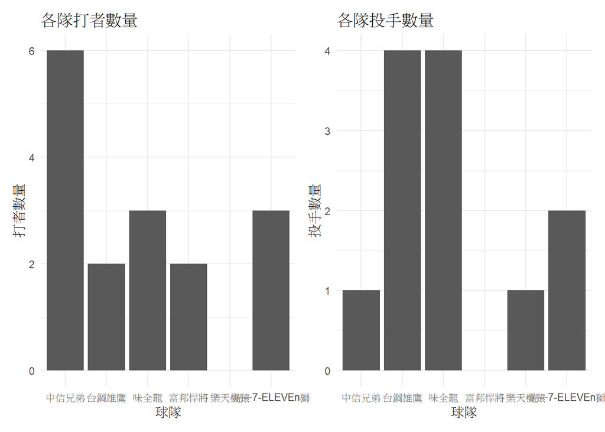

```r
#以圖像方式呈現各中職球隊被選入的打者及投手數量
all_teams <- c("中信兄弟", "台鋼雄鷹", "味全龍", "富邦悍將", "統一7-ELEVEn獅", "樂天桃猿")

p1 = Best_hitter_2024 |> group_by(球隊) |>
  summarise(count = n()) |>
  complete(球隊 = all_teams, fill = list(count = 0)) |>
  ggplot(aes(x = 球隊, y = count)) + geom_bar(stat = "identity") +
  theme_minimal() +
  labs(title = "各隊打者數量", x = "球隊", y = "打者數量")

p2 = Best_pitcher_2024 |> group_by(球隊) |>
  summarise(count = n()) |>
  complete(球隊 = all_teams, fill = list(count = 0)) |>
  ggplot(aes(x = 球隊, y = count)) + geom_bar(stat = "identity") +
  theme_minimal() +
  labs(title = "各隊投手數量", x = "球隊", y = "投手數量")

p1|p2
```

選出打者16位，投手12位，可發現打者部分由中信兄弟、統一7-ELEVEn獅較多，而投手部分則是台鋼雄鷹及味全龍較多

## 六、結論

經上述分析及視覺化的圖例可發現，利用OPS+、ERA+挑選出的優異球員數量，對於球隊戰績來說沒有顯著性，且使用兩個KPI挑選出的球員去回測兩屆國際賽的預測準確率也偏低，可以得知只觀察OPS+、ERA+這兩項指標，會忽略了其他棒球場上的重要數據，且棒球到目前為止也沒有一個可以決定及說明一切的關鍵性指標，因此才會有偏誤，不過，數據確實可以說明及凸顯一些事情，讓我們能夠去細看及分析。

## 七、附錄與結語

1. 專題想法是怎麼來的？

   自己本身就喜歡關注體育賽事，尤其是看中華職棒，也很關心中華隊的國際賽表現，所以覺得說如果自己用數據來分析，去了解自己喜歡的事物，應該是一件相關有趣的事，且自己也一直很好奇到底要怎麼去評斷一名球員的好壞，以及球員對於球隊的影響性，希望自己可以隨著深入觀察及分析，了解教練們的思維。
2. 用了哪些新套件及變量？ 還有用了哪些tidyverse相關指令

   使用了bind_rows、left_join來將資料整併在同一個tibble中，還有intersect來取出交叉項資料，以及!球員 %in% foreign_players來剔除不要的資料。 使用tidyverse的指令像是group_by、summarise、mutate、filter、select，也用到不少繪圖的指令像是labs、scale_y_continuous、facet_wrap、coord_flip、theme_light等
3. 最難的部分是什麼？

   自己覺得最難的是整理資料，當初在蒐集及整理資料時費了好一番功夫，不過後來覺得好像不需要把數據整理的非常整齊，因為也可以透過R語言來整理數據，所以後面才會有一段自己是採用合併的方式組成自己需要的數據。
4. 這份報告要感謝的人

   感謝教授這學期的教導，讓我從原本只會幾個簡單指令及觀念，變成能夠理解後融會貫通，幫助我完成期末報告，且我覺得教授在講課時十分細心，讓我可以深刻的去理解及區間不同程式碼的用途，另外自己覺得PresTree真的很讚，感謝教授願意製作並提供給我們。